# 📺 Netflix Content Analysis Using Python

## 🎯 Objective

Analyze the Netflix Movies and TV Shows dataset to uncover content trends, genre popularity, release patterns, country-wise distribution, ratings, and other valuable business insights using Python.

## 🛠️ Tools & Libraries Used

- Python
- Pandas
- NumPy
- Matplotlib
- Seaborn

## 👨‍💻 Author

Divanshu Singh

## IMPORT LIBRARIES

```python
import pandas as pd
import numpy as np
import matplotlib.pyplot as plt
import seaborn as sns

plt.style.use("ggplot")
```

```python
# Dark theme setup (matches Netflix carousel design)
plt.rcParams['figure.facecolor'] = '#000000'
plt.rcParams['axes.facecolor'] = '#000000'
plt.rcParams['savefig.facecolor'] = '#000000'
plt.rcParams['text.color'] = 'white'
plt.rcParams['axes.labelcolor'] = 'white'
plt.rcParams['xtick.color'] = 'white'
plt.rcParams['ytick.color'] = 'white'
plt.rcParams['axes.edgecolor'] = '#444444'
plt.rcParams['grid.color'] = '#333333'

NETFLIX_RED = '#E50914'
```

## LOAD DATASET

```python
NETFLIX = pd.read_csv(r"C:\Users\Divanshu Singh\Downloads\netflix_titles.csv")
```

```python
NETFLIX
```

|  | show_id | type | title | director | cast | country | date_added | release_year | rating | duration | listed_in | description |
| --- | --- | --- | --- | --- | --- | --- | --- | --- | --- | --- | --- | --- |
| 0 | s1 | Movie | Dick Johnson Is Dead | Kirsten Johnson | NaN | United States | September 25, 2021 | 2020 | PG-13 | 90 min | Documentaries | As her father nears the end of his life, filmm... |
| 1 | s2 | TV Show | Blood & Water | NaN | Ama Qamata, Khosi Ngema, Gail Mabalane, Thaban... | South Africa | September 24, 2021 | 2021 | TV-MA | 2 Seasons | International TV Shows, TV Dramas, TV Mysteries | After crossing paths at a party, a Cape Town t... |
| 2 | s3 | TV Show | Ganglands | Julien Leclercq | Sami Bouajila, Tracy Gotoas, Samuel Jouy, Nabi... | NaN | September 24, 2021 | 2021 | TV-MA | 1 Season | Crime TV Shows, International TV Shows, TV Act... | To protect his family from a powerful drug lor... |
| 3 | s4 | TV Show | Jailbirds New Orleans | NaN | NaN | NaN | September 24, 2021 | 2021 | TV-MA | 1 Season | Docuseries, Reality TV | Feuds, flirtations and toilet talk go down amo... |
| 4 | s5 | TV Show | Kota Factory | NaN | Mayur More, Jitendra Kumar, Ranjan Raj, Alam K... | India | September 24, 2021 | 2021 | TV-MA | 2 Seasons | International TV Shows, Romantic TV Shows, TV ... | In a city of coaching centers known to train I... |
| ... | ... | ... | ... | ... | ... | ... | ... | ... | ... | ... | ... | ... |
| 8802 | s8803 | Movie | Zodiac | David Fincher | Mark Ruffalo, Jake Gyllenhaal, Robert Downey J... | United States | November 20, 2019 | 2007 | R | 158 min | Cult Movies, Dramas, Thrillers | A political cartoonist, a crime reporter and a... |
| 8803 | s8804 | TV Show | Zombie Dumb | NaN | NaN | NaN | July 1, 2019 | 2018 | TV-Y7 | 2 Seasons | Kids' TV, Korean TV Shows, TV Comedies | While living alone in a spooky town, a young g... |
| 8804 | s8805 | Movie | Zombieland | Ruben Fleischer | Jesse Eisenberg, Woody Harrelson, Emma Stone, ... | United States | November 1, 2019 | 2009 | R | 88 min | Comedies, Horror Movies | Looking to survive in a world taken over by zo... |
| 8805 | s8806 | Movie | Zoom | Peter Hewitt | Tim Allen, Courteney Cox, Chevy Chase, Kate Ma... | United States | January 11, 2020 | 2006 | PG | 88 min | Children & Family Movies, Comedies | Dragged from civilian life, a former superhero... |
| 8806 | s8807 | Movie | Zubaan | Mozez Singh | Vicky Kaushal, Sarah-Jane Dias, Raaghav Chanan... | India | March 2, 2019 | 2015 | TV-14 | 111 min | Dramas, International Movies, Music & Musicals | A scrappy but poor boy worms his way into a ty... |

8807 rows × 12 columns

```python
NETFLIX.head()
```

|  | show_id | type | title | director | cast | country | date_added | release_year | rating | duration | listed_in | description |
| --- | --- | --- | --- | --- | --- | --- | --- | --- | --- | --- | --- | --- |
| 0 | s1 | Movie | Dick Johnson Is Dead | Kirsten Johnson | NaN | United States | September 25, 2021 | 2020 | PG-13 | 90 min | Documentaries | As her father nears the end of his life, filmm... |
| 1 | s2 | TV Show | Blood & Water | NaN | Ama Qamata, Khosi Ngema, Gail Mabalane, Thaban... | South Africa | September 24, 2021 | 2021 | TV-MA | 2 Seasons | International TV Shows, TV Dramas, TV Mysteries | After crossing paths at a party, a Cape Town t... |
| 2 | s3 | TV Show | Ganglands | Julien Leclercq | Sami Bouajila, Tracy Gotoas, Samuel Jouy, Nabi... | NaN | September 24, 2021 | 2021 | TV-MA | 1 Season | Crime TV Shows, International TV Shows, TV Act... | To protect his family from a powerful drug lor... |
| 3 | s4 | TV Show | Jailbirds New Orleans | NaN | NaN | NaN | September 24, 2021 | 2021 | TV-MA | 1 Season | Docuseries, Reality TV | Feuds, flirtations and toilet talk go down amo... |
| 4 | s5 | TV Show | Kota Factory | NaN | Mayur More, Jitendra Kumar, Ranjan Raj, Alam K... | India | September 24, 2021 | 2021 | TV-MA | 2 Seasons | International TV Shows, Romantic TV Shows, TV ... | In a city of coaching centers known to train I... |

```python
NETFLIX.tail()
```

|  | show_id | type | title | director | cast | country | date_added | release_year | rating | duration | listed_in | description |
| --- | --- | --- | --- | --- | --- | --- | --- | --- | --- | --- | --- | --- |
| 8802 | s8803 | Movie | Zodiac | David Fincher | Mark Ruffalo, Jake Gyllenhaal, Robert Downey J... | United States | November 20, 2019 | 2007 | R | 158 min | Cult Movies, Dramas, Thrillers | A political cartoonist, a crime reporter and a... |
| 8803 | s8804 | TV Show | Zombie Dumb | NaN | NaN | NaN | July 1, 2019 | 2018 | TV-Y7 | 2 Seasons | Kids' TV, Korean TV Shows, TV Comedies | While living alone in a spooky town, a young g... |
| 8804 | s8805 | Movie | Zombieland | Ruben Fleischer | Jesse Eisenberg, Woody Harrelson, Emma Stone, ... | United States | November 1, 2019 | 2009 | R | 88 min | Comedies, Horror Movies | Looking to survive in a world taken over by zo... |
| 8805 | s8806 | Movie | Zoom | Peter Hewitt | Tim Allen, Courteney Cox, Chevy Chase, Kate Ma... | United States | January 11, 2020 | 2006 | PG | 88 min | Children & Family Movies, Comedies | Dragged from civilian life, a former superhero... |
| 8806 | s8807 | Movie | Zubaan | Mozez Singh | Vicky Kaushal, Sarah-Jane Dias, Raaghav Chanan... | India | March 2, 2019 | 2015 | TV-14 | 111 min | Dramas, International Movies, Music & Musicals | A scrappy but poor boy worms his way into a ty... |

```python
print("Rows :", NETFLIX.shape[0])
print("Columns :", NETFLIX.shape[1])
```

```
Rows : 8807
Columns : 12
```

```python
NETFLIX.columns
```

```
Index(['show_id', 'type', 'title', 'director', 'cast', 'country', 'date_added',
       'release_year', 'rating', 'duration', 'listed_in', 'description'],
      dtype='str')
```

```python
NETFLIX.info()
```

```
<class 'pandas.DataFrame'>
RangeIndex: 8807 entries, 0 to 8806
Data columns (total 12 columns):
 #   Column        Non-Null Count  Dtype
---  ------        --------------  -----
 0   show_id       8807 non-null   str
 1   type          8807 non-null   str
 2   title         8807 non-null   str
 3   director      6173 non-null   str
 4   cast          7982 non-null   str
 5   country       7976 non-null   str
 6   date_added    8797 non-null   str
 7   release_year  8807 non-null   int64
 8   rating        8803 non-null   str
 9   duration      8804 non-null   str
 10  listed_in     8807 non-null   str
 11  description   8807 non-null   str
dtypes: int64(1), str(11)
memory usage: 825.8 KB
```

```python
NETFLIX.describe()
```

|  | release_year |
| --- | --- |
| count | 8807.000000 |
| mean | 2014.180198 |
| std | 8.819312 |
| min | 1925.000000 |
| 25% | 2013.000000 |
| 50% | 2017.000000 |
| 75% | 2019.000000 |
| max | 2021.000000 |

```python
NETFLIX.sample(5)
```

|  | show_id | type | title | director | cast | country | date_added | release_year | rating | duration | listed_in | description |
| --- | --- | --- | --- | --- | --- | --- | --- | --- | --- | --- | --- | --- |
| 913 | s914 | Movie | Time to Dance | Stanley Menino D'Costa | Sooraj Pancholi, Isabelle Kaif, Rajpal Yadav, ... | India | May 7, 2021 | 2020 | TV-PG | 107 min | Dramas, International Movies, Romantic Movies | When a ballroom dancer’s shot at a crucial tou... |
| 1871 | s1872 | Movie | Super Monsters: Dia de los Monsters | NaN | NaN | Canada | October 9, 2020 | 2020 | TV-Y | 25 min | Children & Family Movies | The Super Monsters celebrate Día de los Muerto... |
| 1960 | s1961 | Movie | Kiss the Ground | Joshua Tickell, Rebecca Harrell Tickell | Woody Harrelson | United States | September 22, 2020 | 2020 | TV-G | 85 min | Documentaries | Science experts and celebrity activists unpack... |
| 3214 | s3215 | Movie | Payday | Cheta Chukwu | Baaj Adebule, Ebiye Victor, Meg Otanwa, Bisola... | Nigeria | November 29, 2019 | 2018 | TV-MA | 110 min | Comedies, Independent Movies, International Mo... | After an expensive night out, two flatmates ge... |
| 4657 | s4658 | Movie | Sierra Burgess Is A Loser | Ian Samuels | Shannon Purser, Kristine Froseth, RJ Cyler, No... | United States | September 7, 2018 | 2018 | PG-13 | 106 min | Comedies, Romantic Movies | A wrong-number text sparks a virtual romance b... |

## Data Cleaning

```python
NETFLIX.isnull().sum()
```

```
show_id            0
type               0
title              0
director        2634
cast             825
country          831
date_added        10
release_year       0
rating             4
duration           3
listed_in          0
description        0
dtype: int64
```

```python
NETFLIX.duplicated().sum()
```

```
np.int64(0)
```

```python
NETFLIX.drop_duplicates(inplace=True)
```

```python
NETFLIX.shape
```

```
(8807, 12)
```

```python
NETFLIX['date_added'] = NETFLIX['date_added'].str.strip()
```

```python
NETFLIX['date_added'] = pd.to_datetime(NETFLIX['date_added'])
```

```python
NETFLIX.dtypes
```

```
show_id                    str
type                       str
title                      str
director                   str
cast                       str
country                    str
date_added      datetime64[us]
release_year             int64
rating                     str
duration                   str
listed_in                  str
description                str
dtype: object
```

```python
NETFLIX['Year Added'] = NETFLIX['date_added'].dt.year
```

```python
NETFLIX['Month Added'] = NETFLIX['date_added'].dt.month_name()
```

```python
NETFLIX['Day Added'] = NETFLIX['date_added'].dt.day_name()
```

```python
NETFLIX.head()
```

|  | show_id | type | title | director | cast | country | date_added | release_year | rating | duration | listed_in | description | Year Added | Month Added | Day Added |
| --- | --- | --- | --- | --- | --- | --- | --- | --- | --- | --- | --- | --- | --- | --- | --- |
| 0 | s1 | Movie | Dick Johnson Is Dead | Kirsten Johnson | NaN | United States | 2021-09-25 | 2020 | PG-13 | 90 min | Documentaries | As her father nears the end of his life, filmm... | 2021.0 | September | Saturday |
| 1 | s2 | TV Show | Blood & Water | NaN | Ama Qamata, Khosi Ngema, Gail Mabalane, Thaban... | South Africa | 2021-09-24 | 2021 | TV-MA | 2 Seasons | International TV Shows, TV Dramas, TV Mysteries | After crossing paths at a party, a Cape Town t... | 2021.0 | September | Friday |
| 2 | s3 | TV Show | Ganglands | Julien Leclercq | Sami Bouajila, Tracy Gotoas, Samuel Jouy, Nabi... | NaN | 2021-09-24 | 2021 | TV-MA | 1 Season | Crime TV Shows, International TV Shows, TV Act... | To protect his family from a powerful drug lor... | 2021.0 | September | Friday |
| 3 | s4 | TV Show | Jailbirds New Orleans | NaN | NaN | NaN | 2021-09-24 | 2021 | TV-MA | 1 Season | Docuseries, Reality TV | Feuds, flirtations and toilet talk go down amo... | 2021.0 | September | Friday |
| 4 | s5 | TV Show | Kota Factory | NaN | Mayur More, Jitendra Kumar, Ranjan Raj, Alam K... | India | 2021-09-24 | 2021 | TV-MA | 2 Seasons | International TV Shows, Romantic TV Shows, TV ... | In a city of coaching centers known to train I... | 2021.0 | September | Friday |

## 🧹 Data Cleaning

The dataset was cleaned by checking for missing values and duplicate records. The `date_added` column was converted to datetime format, and new columns such as **Year Added**, **Month Added**, and **Day Added** were extracted to support time-based analysis.

# 📊 Exploratory Data Analysis (EDA)

## Overview

Exploratory Data Analysis (EDA) is performed to understand the distribution, characteristics, and trends within the Netflix dataset. This section answers key business questions using descriptive statistics and visualizations.

The analysis focuses on:

- Content Type Distribution
- Country-wise Content
- Genre Analysis
- Rating Distribution
- Release Trends
- Directors and Cast Analysis
- Movie Duration Analysis

## 🎬 1. Content Type Distribution

This analysis shows the total number of Movies and TV Shows available on Netflix.

```python
NETFLIX['type'].value_counts()
```

```
type
Movie      6131
TV Show    2676
Name: count, dtype: int64
```

## 🎥 2. Total Movies

```python
movies = NETFLIX[NETFLIX['type'] == 'Movie']

print("Total Movies :", len(movies))
```

```
Total Movies : 6131
```

## 📺 3. Total TV Shows

```python
tvshows = NETFLIX[NETFLIX['type'] == 'TV Show']

print("Total TV Shows :", len(tvshows))
```

```
Total TV Shows : 2676
```

```python
print("Total Countries :", NETFLIX['country'].nunique())
```

```
Total Countries : 748
```

## ⭐ 5. Content Ratings

```python
NETFLIX['rating'].value_counts()
```

```
rating
TV-MA       3207
TV-14       2160
TV-PG        863
R            799
PG-13        490
TV-Y7        334
TV-Y         307
PG           287
TV-G         220
NR            80
G             41
TV-Y7-FV       6
NC-17          3
UR             3
74 min         1
84 min         1
66 min         1
Name: count, dtype: int64
```

## 🎬 6. Total Directors

```python
print("Total Directors :", NETFLIX['director'].nunique())
```

```
Total Directors : 4528
```

```python
print("Total Genres :", NETFLIX['listed_in'].nunique())
```

```
Total Genres : 514
```

## 📅 8. Release Year Range

```python
print("Oldest Release :", NETFLIX['release_year'].min())
print("Latest Release :", NETFLIX['release_year'].max())
```

```
Oldest Release : 1925
Latest Release : 2021
```

## 🌎 9. Top 10 Countries by Content

```python
NETFLIX['country'].value_counts().head(10)
```

```
country
United States     2818
India              972
United Kingdom     419
Japan              245
South Korea        199
Canada             181
Spain              145
France             124
Mexico             110
Egypt              106
Name: count, dtype: int64
```

# 📈 Data Visualization

## Overview

Data visualization helps us understand patterns, trends, and relationships within the Netflix dataset. The following charts provide insights into Netflix's content library, including content types, countries, genres, ratings, release years, and more.

## 🎬 1. Movies vs TV Shows

This chart compares the number of Movies and TV Shows available on Netflix.

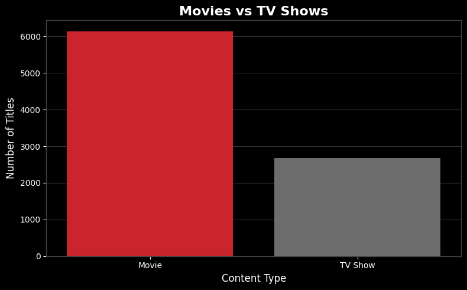

```python
plt.figure(figsize=(8,5))
sns.countplot(data=NETFLIX,
              x='type',
              hue='type',
              palette=[NETFLIX_RED, '#6D6D6D'],
              legend=False)
plt.title("Movies vs TV Shows", fontsize=16, fontweight='bold', color='white')
plt.xlabel("Content Type")
plt.ylabel("Number of Titles")
plt.tight_layout()
plt.savefig("movies_vs_tvshows.png", dpi=300, bbox_inches='tight', facecolor='black')
plt.show()
```

## 🥧 2. Movies vs TV Shows Percentage

This pie chart shows the percentage distribution of Movies and TV Shows.

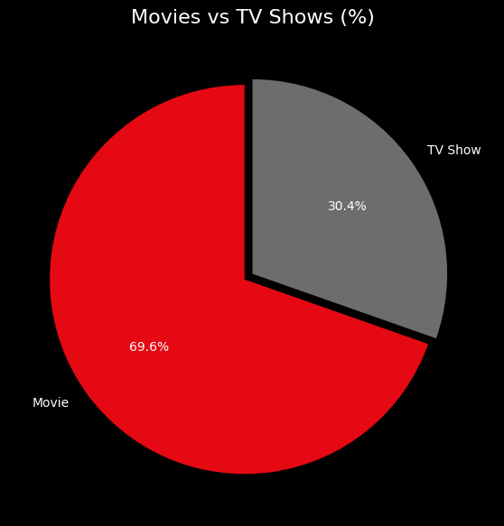

```python
content = NETFLIX['type'].value_counts()
plt.figure(figsize=(7,7), facecolor='black')
plt.pie(content, labels=content.index, autopct='%1.1f%%', startangle=90,
        explode=(0.05,0), colors=[NETFLIX_RED, '#6D6D6D'],
        textprops={'color':'white'})
plt.title("Movies vs TV Shows (%)", fontsize=16, color='white')
plt.savefig("movies_vs_tvshows_pie.png", dpi=300, bbox_inches='tight', facecolor='black')
plt.show()
```

## 🌍 3. Top 10 Countries by Content

This chart displays the countries with the highest number of Netflix titles.

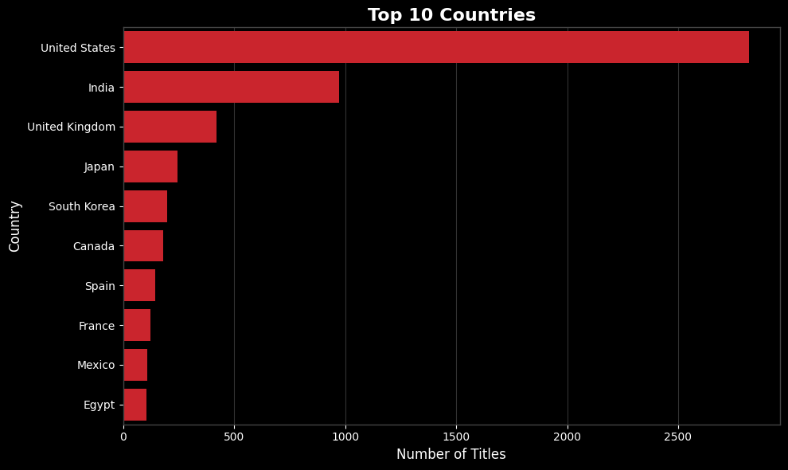

```python
top_country = NETFLIX['country'].value_counts().head(10)
plt.figure(figsize=(10,6))
sns.barplot(x=top_country.values,
            y=top_country.index,
            color=NETFLIX_RED)
plt.title("Top 10 Countries", fontsize=16, fontweight='bold', color='white')
plt.xlabel("Number of Titles")
plt.ylabel("Country")
plt.tight_layout()
plt.savefig("top_10_countries.png", dpi=300, bbox_inches='tight', facecolor='black')
plt.show()
```

## ⭐ 4. Rating Distribution

This chart shows the distribution of content ratings on Netflix.

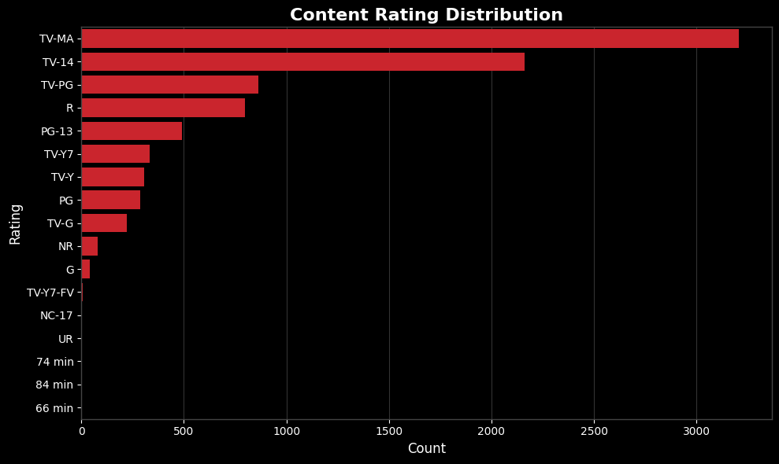

```python
plt.figure(figsize=(10,6))
sns.countplot(y='rating', data=NETFLIX,
              order=NETFLIX['rating'].value_counts().index,
              color=NETFLIX_RED)
plt.title("Content Rating Distribution", fontsize=16, fontweight='bold', color='white')
plt.xlabel("Count")
plt.ylabel("Rating")
plt.tight_layout()
plt.savefig("content_rating_distribution.png", dpi=300, bbox_inches='tight', facecolor='black')
plt.show()
```

## 📅 5. Release Year Distribution

This histogram shows how Netflix content is distributed by release year.

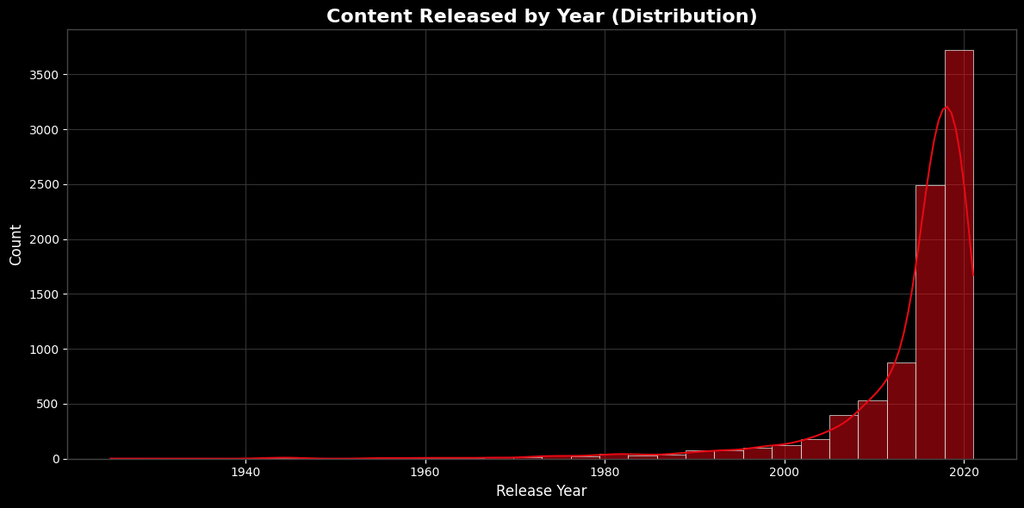

```python
plt.figure(figsize=(12,6))
sns.histplot(NETFLIX['release_year'], bins=30, kde=True, color=NETFLIX_RED)
plt.title("Content Released by Year (Distribution)", fontsize=16, fontweight='bold', color='white')
plt.xlabel("Release Year")
plt.ylabel("Count")
plt.tight_layout()
plt.savefig("release_year_distribution.png", dpi=300, bbox_inches='tight', facecolor='black')
plt.show()
```

### 💡 Key Insights

- Movies represent a larger share of Netflix's catalog than TV Shows.
- The United States contributes the highest number of titles.
- TV-MA is one of the most common content ratings.
- Netflix expanded its content library significantly after 2015.

## 🎭 6. Top 10 Genres

This chart displays the most popular genres available on Netflix.

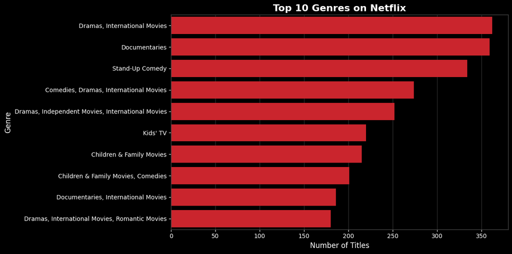

```python
top_genres = NETFLIX['listed_in'].value_counts().head(10)
plt.figure(figsize=(12,6))
sns.barplot(
    x=top_genres.values,
    y=top_genres.index,
    color=NETFLIX_RED
)
plt.title("Top 10 Genres on Netflix", fontsize=16, fontweight='bold', color='white')
plt.xlabel("Number of Titles")
plt.ylabel("Genre")
plt.tight_layout()
plt.savefig("top_10_genres.png", dpi=300, bbox_inches='tight', facecolor='black')
plt.show()
```

### 💡 Insight

Drama and International Movies are among the most popular genres on Netflix, showing a strong focus on diverse global entertainment.

## 🎬 7. Top 10 Directors

This chart highlights the directors with the highest number of titles on Netflix.

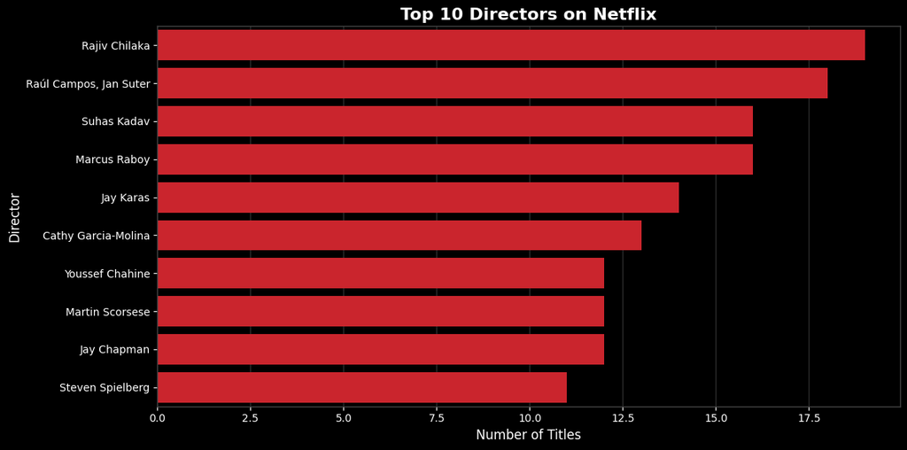

```python
top_directors = NETFLIX['director'].value_counts().head(10)
plt.figure(figsize=(12,6))
sns.barplot(
    x=top_directors.values,
    y=top_directors.index,
    color=NETFLIX_RED
)
plt.title("Top 10 Directors on Netflix", fontsize=16, fontweight='bold', color='white')
plt.xlabel("Number of Titles")
plt.ylabel("Director")
plt.tight_layout()
plt.savefig("top_10_directors.png", dpi=300, bbox_inches='tight', facecolor='black')
plt.show()
```